# MK Praktikum Unggulan Universitas Gunadarma

# Nama Mata Kuliah: Praktikum Komputasi Big Data (Tingkat 2)

# Pertemuan VII

Pada pertemuan ini Anda akan melanjutkan tahapan pengolahan data yaitu data training dan model generation.

# Import Dataset

```python
# Import library
import pandas as pd
import numpy as np

# Import dataset
data = pd.read_csv('https://gitlab.com/andreass.bayu/file-directory/-/raw/main/adult.csv')

# Lihat 5 data teratas
data.head(5)
```

|  | age | workclass | fnlwgt | education | educational-num | marital-status | occupation | relationship | race | gender | capital-gain | capital-loss | hours-per-week | native-country | income |
| --- | --- | --- | --- | --- | --- | --- | --- | --- | --- | --- | --- | --- | --- | --- | --- |
| 0 | 25 | Private | 226802 | 11th | 7 | Never-married | Machine-op-inspct | Own-child | Black | Male | 0 | 0 | 40 | United-States | <=50K |
| 1 | 38 | Private | 89814 | HS-grad | 9 | Married-civ-spouse | Farming-fishing | Husband | White | Male | 0 | 0 | 50 | United-States | <=50K |
| 2 | 28 | Local-gov | 336951 | Assoc-acdm | 12 | Married-civ-spouse | Protective-serv | Husband | White | Male | 0 | 0 | 40 | United-States | >50K |
| 3 | 44 | Private | 160323 | Some-college | 10 | Married-civ-spouse | Machine-op-inspct | Husband | Black | Male | 7688 | 0 | 40 | United-States | >50K |
| 4 | 18 | ? | 103497 | Some-college | 10 | Never-married | ? | Own-child | White | Female | 0 | 0 | 30 | United-States | <=50K |

# Review Dataset

```python
# Lihat statistik deskripsi data dari tiap kolom dengan menggunakan fungsi describe
data.describe()
```

|  | age | fnlwgt | educational-num | capital-gain | capital-loss | hours-per-week |
| --- | --- | --- | --- | --- | --- | --- |
| count | 48842.000000 | 4.884200e+04 | 48842.000000 | 48842.000000 | 48842.000000 | 48842.000000 |
| mean | 38.643585 | 1.896641e+05 | 10.078089 | 1079.067626 | 87.502314 | 40.422382 |
| std | 13.710510 | 1.056040e+05 | 2.570973 | 7452.019058 | 403.004552 | 12.391444 |
| min | 17.000000 | 1.228500e+04 | 1.000000 | 0.000000 | 0.000000 | 1.000000 |
| 25% | 28.000000 | 1.175505e+05 | 9.000000 | 0.000000 | 0.000000 | 40.000000 |
| 50% | 37.000000 | 1.781445e+05 | 10.000000 | 0.000000 | 0.000000 | 40.000000 |
| 75% | 48.000000 | 2.376420e+05 | 12.000000 | 0.000000 | 0.000000 | 45.000000 |
| max | 90.000000 | 1.490400e+06 | 16.000000 | 99999.000000 | 4356.000000 | 99.000000 |

```python
# Lihat tipe data dari tiap kolom dengan menggunakan fungsi dtypes
data.dtypes
```

```
age                int64
workclass            str
fnlwgt             int64
education            str
educational-num    int64
marital-status       str
occupation           str
relationship         str
race                 str
gender               str
capital-gain       int64
capital-loss       int64
hours-per-week     int64
native-country       str
income               str
dtype: object
```

```python
# Melihat jumlah atribut dan dimensi data (baris dan kolom) dengan menggunakan fungsi shape
data.shape
```

```
(48842, 15)
```

```python
# Menghitung dan melihat jumlah data per label kelas
for col in data.columns:
  if pd.api.types.is_string_dtype(data[col]):
    print('Attribute name:',col)
    print('-------------------')
    print(data[col].value_counts())
    print('-------------------')
```

```
Attribute name: workclass
-------------------
workclass
Private             33906
Self-emp-not-inc     3862
Local-gov            3136
?                    2799
State-gov            1981
Self-emp-inc         1695
Federal-gov          1432
Without-pay            21
Never-worked           10
Name: count, dtype: int64
-------------------
Attribute name: education
-------------------
education
HS-grad         15784
Some-college    10878
Bachelors        8025
Masters          2657
Assoc-voc        2061
11th             1812
Assoc-acdm       1601
10th             1389
7th-8th           955
Prof-school       834
9th               756
12th              657
Doctorate         594
5th-6th           509
1st-4th           247
Preschool          83
Name: count, dtype: int64
-------------------
Attribute name: marital-status
-------------------
marital-status
Married-civ-spouse       22379
Never-married            16117
```

[output cut: 94 more lines]

```
Yugoslavia                       23
Outlying-US(Guam-USVI-etc)       23
Scotland                         21
Honduras                         20
Hungary                          19
Holand-Netherlands                1
Name: count, dtype: int64
-------------------
Attribute name: income
-------------------
income
<=50K    37155
>50K     11687
Name: count, dtype: int64
-------------------
```

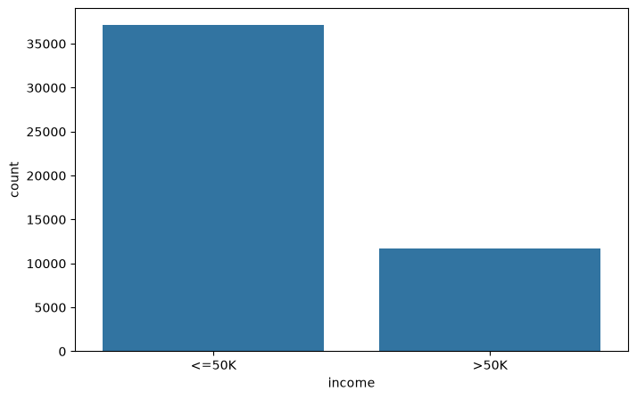

```python
# Import library seaborn untuk visualisasi
import seaborn as sns
import matplotlib.pyplot as plt
%matplotlib inline

# Plot figure untuk menentukan distribusi kelas
plt.figure(figsize=(8,5))

# Menghitung baris setiap kelas
sns.countplot(x="income", data=data)
```

**Diketahui bahwa dataset memiliki distribusi kelas yang tidak seimbang (imbalanced) sehingga secara teknis akan digunakan teknik untuk menangani data yang tidak seimbang.**

# Dataset preparation

```python
# Buat salinan dataframe
df = data.copy(deep = True)

# Mengubah nilai "?" nilai ke bentuk Na / NaN untuk diproses lebih lanjut
for col in data.columns:
  df[[col]] = data[[col]].replace('?',np.nan)
```

```python
# Melakukan seleksi kolom fitur/feature columns dari dataset
null_data = df.iloc[:,:-1]

# Temukan nilai null untuk semua atribut dan jumlahkan total nilai null
null_data.isnull().sum()
```

```
age                   0
workclass          2799
fnlwgt                0
education             0
educational-num       0
marital-status        0
occupation         2809
relationship          0
race                  0
gender                0
capital-gain          0
capital-loss          0
hours-per-week        0
native-country      857
dtype: int64
```

```python
# Hapus (drop) semua baris yang memiliki nilai null
df = df.dropna()

# Pilih kolom fitur (feature columns) dari dataset
null_data = df.iloc[:,:-1]

# Cek ulang nilai null
null_data.isnull().sum()
```

```
age                0
workclass          0
fnlwgt             0
education          0
educational-num    0
marital-status     0
occupation         0
relationship       0
race               0
gender             0
capital-gain       0
capital-loss       0
hours-per-week     0
native-country     0
dtype: int64
```

**StandardScaler** *adalah class dari sklearn untuk melakukan normalisasi data agar data yang digunakan tidak memiliki penyimpangan yang besar.*

```python
# Import library standard scaler
from sklearn.preprocessing import StandardScaler

# Buat dataframe dengan tipe data int64
colname= []
for col in df.columns:
  if pd.api.types.is_integer_dtype(df[col]):
      colname.append(col)

# Buat salinan dataset untuk keperluan persiapan data (data preparation)
df_copy = df.copy(deep = True)
df_fe = df.copy()

# Buat dataframe untuk fitur kategoris (categorical features)
df_fe.drop('income',axis='columns', inplace=True)
df_fe.drop(colname,axis='columns', inplace=True)

# Buat dataframe untuk kelas target (target class)
df_cl = df.copy()
df_cl.drop(df_copy.iloc[:,:-1],axis='columns', inplace=True)

# Membuat objek scaler (scaler object)
std_scaler = StandardScaler()
std_scaler

# Normalisasikan atribut numerik dan tetapkan ke dalam dataframe baru
df_norm = pd.DataFrame(std_scaler.fit_transform(df_copy[colname]), columns=colname)
```

```python
# Import library Ordinal Encoder dari package library sklearn.preprocessing
from sklearn.preprocessing import OrdinalEncoder
ord_enc = OrdinalEncoder()

# Encode fitur kategoris/categorical features menjadi fitur numerik (numerical features)
for col in df_fe.columns[:]:
  if pd.api.types.is_string_dtype(df_fe[col]):
    df_fe[col] = ord_enc.fit_transform(df_fe[[col]])

# Encode label kategorikal (categorical label) menjadi label biner (binary label)
df_cl["income"] = np.where(df_cl["income"].str.contains(">50K"), 0, 1)
```

```python
# Masukkan kolom id ke dataset yang berbeda
df_norm.insert(0, 'id', range(0, 0 + len(df_norm)))
df_fe.insert(0, 'id', range(0, 0 + len(df_fe)))
df_cl.insert(0, 'id', range(0, 0 + len(df_cl)))

# Lihat shapes dataset yang telah di proses
print(df_norm.shape)
print(df_fe.shape)
print(df_cl.shape)
```

```
(45222, 7)
(45222, 9)
(45222, 2)
```

```python
# Gabungkan semua dataset
df_feature = pd.merge(df_norm,df_fe, on=["id"])
df_final = pd.merge(df_feature,df_cl, on=["id"])

# Drop kolom id dari gabungan dataset
df_final.drop('id',axis='columns', inplace=True)

# Lihat 5 data teratas dari gabungan dataset
df_final.head(5)
```

|  | age | fnlwgt | educational-num | capital-gain | capital-loss | hours-per-week | workclass | education | marital-status | occupation | relationship | race | gender | native-country | income |
| --- | --- | --- | --- | --- | --- | --- | --- | --- | --- | --- | --- | --- | --- | --- | --- |
| 0 | -1.024983 | 0.350889 | -1.221559 | -0.146733 | -0.21878 | -0.078120 | 2.0 | 1.0 | 4.0 | 6.0 | 3.0 | 2.0 | 1.0 | 38.0 | 1 |
| 1 | -0.041455 | -0.945878 | -0.438122 | -0.146733 | -0.21878 | 0.754701 | 2.0 | 11.0 | 2.0 | 4.0 | 0.0 | 4.0 | 1.0 | 38.0 | 1 |
| 2 | -0.798015 | 1.393592 | 0.737034 | -0.146733 | -0.21878 | -0.078120 | 1.0 | 7.0 | 2.0 | 10.0 | 0.0 | 4.0 | 1.0 | 38.0 | 0 |
| 3 | 0.412481 | -0.278420 | -0.046403 | 0.877467 | -0.21878 | -0.078120 | 2.0 | 15.0 | 2.0 | 6.0 | 0.0 | 2.0 | 1.0 | 38.0 | 0 |
| 4 | -0.344079 | 0.084802 | -1.613277 | -0.146733 | -0.21878 | -0.910942 | 2.0 | 0.0 | 4.0 | 7.0 | 1.0 | 4.0 | 1.0 | 38.0 | 1 |

# Visualization

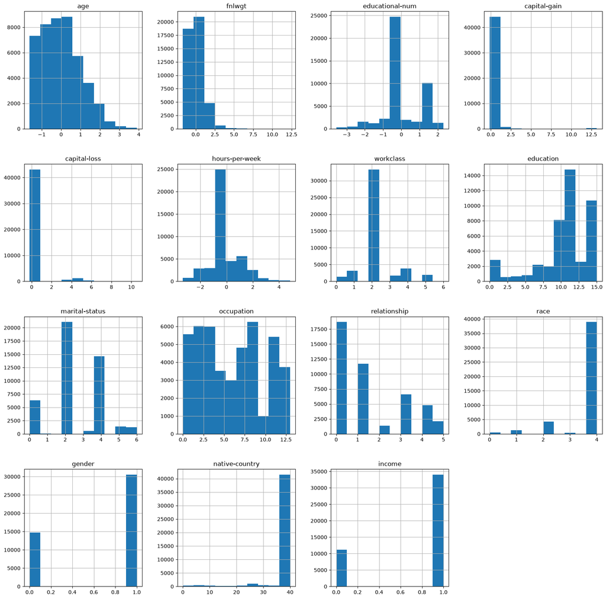

```python
p = df_final.hist(figsize = (20,20))
```

**Scatter matrix plot** adalah plot yang digunakan untuk membuat sekumpulan scatter plot dari beberapa pasang variabel. Hal ini sangat bermanfaat terutama ketika ingin menganalisis bagaimana bentuk hubungan antar variabel. Plot ini sangat bermanfaat untuk digunakan untuk data yang ukurannya tidak terlalu besar. Untuk menggunakan scatter matrix kita harus memanggil fungsi *scatter_matrix* dari *pandas.plotting*

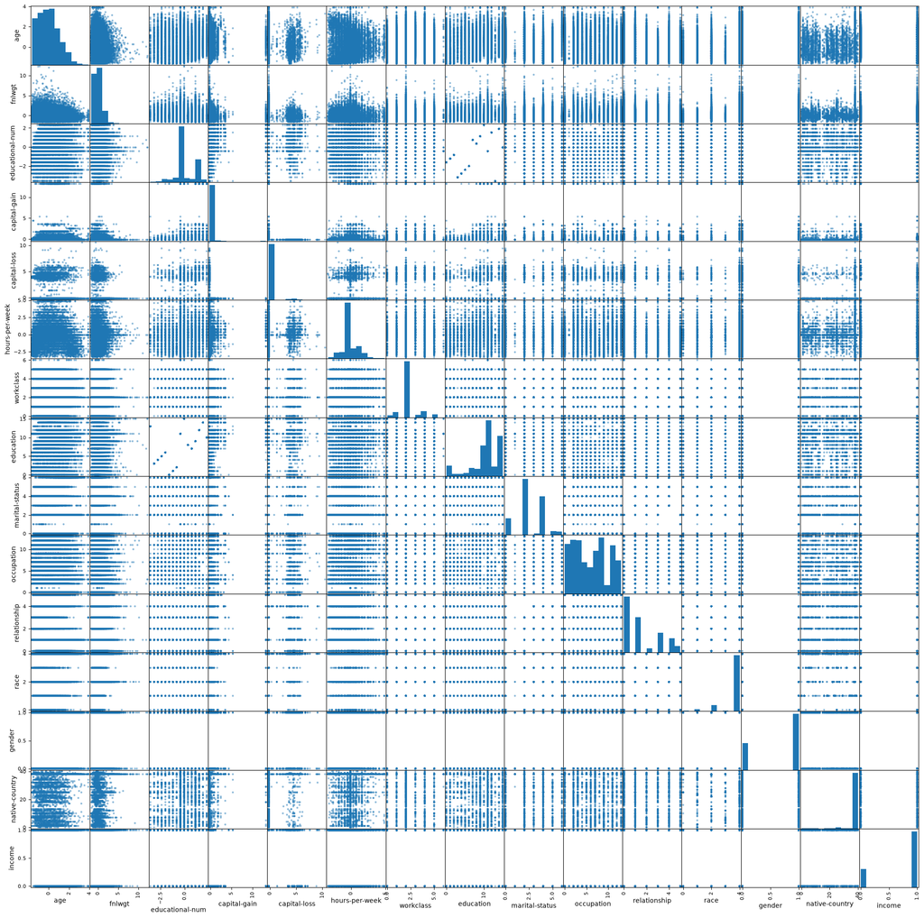

```python
from pandas.plotting import scatter_matrix

p=scatter_matrix(df_final,figsize=(25, 25))
```

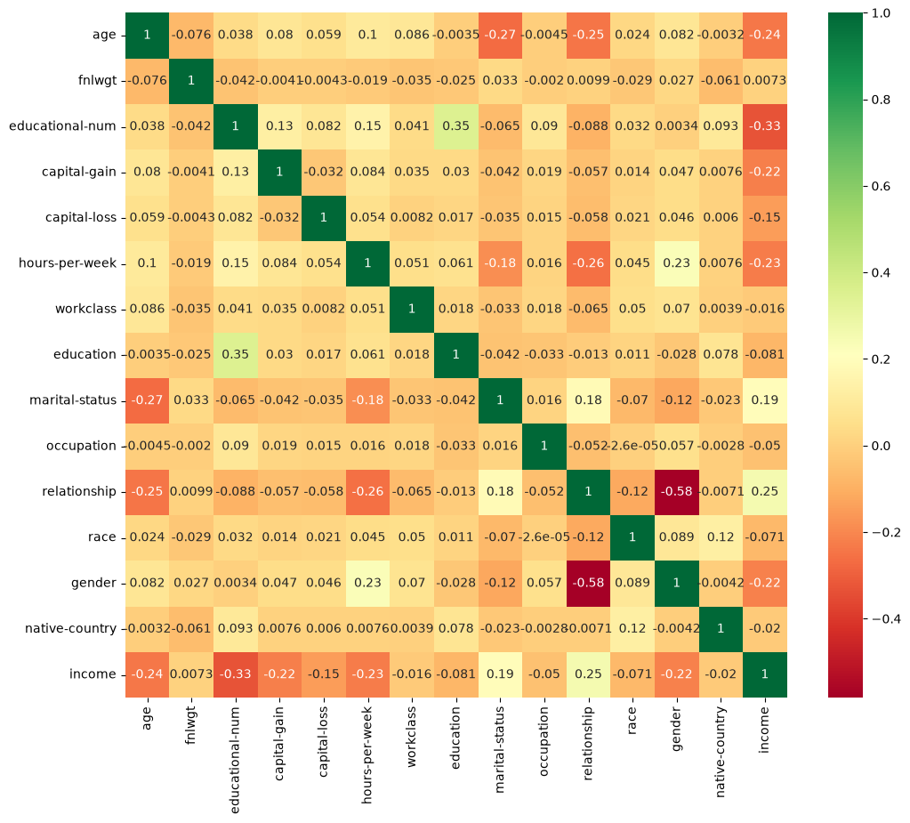

```python
# Buat visualisasi korelasi data dengan heatmap
import seaborn as sns
import matplotlib.pyplot as plt

# Plot heatmap
plt.figure(figsize=(12,10))
p=sns.heatmap(df_final.corr(), annot=True,cmap ='RdYlGn')
```

# Proses Modelling dengan KNN

```python
import numpy as np
from sklearn.model_selection import KFold

# Kolom terakhir adalah label (income), jadi hanya kolom sebelumnya yang menjadi fitur
X=df_final.iloc[:,:-1].to_numpy()
y=df_final.iloc[:,-1:].to_numpy()
kf = KFold(n_splits=5)
kf.get_n_splits(X)

print(kf)

for train_index, test_index in kf.split(X):
    print("TRAIN:", train_index, "TEST:", test_index)
    x_train, x_test = X[train_index], X[test_index]
    y_train, y_test = y[train_index], y[test_index]
```

```
KFold(n_splits=5, random_state=None, shuffle=False)
TRAIN: [ 9045  9046  9047 ... 45219 45220 45221] TEST: [   0    1    2 ... 9042 9043 9044]
TRAIN: [    0     1     2 ... 45219 45220 45221] TEST: [ 9045  9046  9047 ... 18087 18088 18089]
TRAIN: [    0     1     2 ... 45219 45220 45221] TEST: [18090 18091 18092 ... 27131 27132 27133]
TRAIN: [    0     1     2 ... 45219 45220 45221] TEST: [27134 27135 27136 ... 36175 36176 36177]
TRAIN: [    0     1     2 ... 36175 36176 36177] TEST: [36178 36179 36180 ... 45219 45220 45221]
```

```python
print('-------- x axis test ----------')
print(x_test)
print('-------- x axis train ---------')
print(x_train)
print('-------- y axis test ----------')
print(y_test)
print('-------- y axis train ---------')
print(y_train)

print('*******************************')
```

```
-------- x axis test ----------
[[ 0.63944887  1.45787715 -0.43812161 ...  2.          1.
  38.        ]
 [ 1.24469679 -1.49349376 -0.046403   ...  4.          1.
  38.        ]
 [-0.26842301 -0.14603391 -0.046403   ...  4.          1.
  38.        ]
 ...
 [ 1.47166476 -0.35805983 -0.43812161 ...  4.          0.
  38.        ]
 [-1.25195088  0.11127873 -0.43812161 ...  4.          1.
  38.        ]
 [ 1.01772882  0.92951628 -0.43812161 ...  4.          0.
  38.        ]]
-------- x axis train ---------
[[-1.02498291  0.35088942 -1.22155881 ...  2.          1.
  38.        ]
 [-0.04145504 -0.94587846 -0.43812161 ...  4.          1.
  38.        ]
 [-0.79801494  1.39359159  0.73703421 ...  4.          1.
  38.        ]
 ...
 [-0.344079   -0.77568407 -0.43812161 ...  4.          1.
  10.        ]
 [ 0.86641684  0.04524191  1.52047141 ...  2.          1.
  37.        ]
 [-0.64670296  0.84029651 -0.43812161 ...  2.          0.
  38.        ]]
-------- y axis test ----------
[[1]
 [1]
 [1]
 ...
 [1]
 [1]
 [0]]
-------- y axis train ---------
[[1]
 [1]
 [0]
 ...
 [0]
 [1]
 [1]]
```

```
Nilai k KNN yang optimal adalah 18
Skor optimalnya adalah 0.83
```

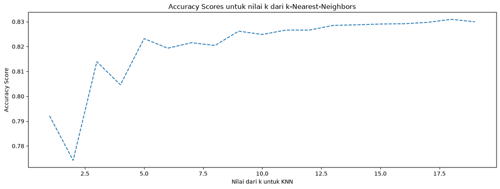

```python
# Import library model KNN dengan alias 'KNeighborsClassifier'
from sklearn.neighbors import KNeighborsClassifier
import sklearn.metrics as metrics
import matplotlib.pyplot as plt

# Buat variabel kosong untuk menyimpan metrik KNN/KNN metrics
scores=[]

# Kita coba nilai k yang berbeda untuk KNN (dari k=1 sampai k=20)
lrange=list(range(1,20))

# Proses perulangan untuk KNN
for k in lrange:
  knn=KNeighborsClassifier(n_neighbors=k) # Masukkan nilai k dan ukuran 'jarak'
  knn.fit(x_train,y_train.ravel()) # Masukan data train/data latih untuk melatih KNN
  y_pred=knn.predict(x_test) # Lihat prediksi KNN dengan memasukkan data uji
  scores.append(metrics.accuracy_score(y_test,y_pred)) # Tambahkan performance metric akurasi
plt.figure(2,figsize=(15,5))

optimal_k = lrange[scores.index(max(scores))]
print("Nilai k KNN yang optimal adalah %d" % optimal_k)
print("Skor optimalnya adalah %.2f" % max(scores))

# Visualisasikan hasilnya
plt.plot(lrange, scores,ls='dashed')
plt.xlabel('Nilai dari k untuk KNN')
plt.ylabel('Accuracy Score')
plt.title('Accuracy Scores untuk nilai k dari k-Nearest-Neighbors')
plt.show()
```

## Tugas Analisis

Berdasarkan hasil percobaan KNN di atas, buatlah hasil analisis dengan menjawab pertanyaan berikut:

1. Pada hasil diagram heatmap, terlihat banyak konfigurasi warna dan nilai yang ditampilkan. Jelaskan arti kolom berwarna merah pada hasil diagram heatmap yang dihasilkan! Pasangan variabel apa saja yang berwarna merah?
2. Apa yang terjadi jika nilai test size diganti menjadi 0.3 kemudian 0.2 dan 0.1?
3. Buatlah tabel yang berisi hasil pengujian Anda dan sertakan beberapa nilai k dan nilai akurasi untuk masing-masing skenario uji!
4. Apakah terjadi perbedaan nilai akurasi model? Jika ya, jelaskan pendapat Anda mengapa hal tersebut bisa terjadi.
5. Berapa nilai presisi dan recall dari masing-masing model yang Anda coba, serta jelaskan arti dari nilai tersebut.

```python
# No 1
# Heatmap memakai cmap 'RdYlGn': MERAH = korelasi negatif, HIJAU = korelasi positif
corr = df_final.corr()
mask = np.triu(np.ones_like(corr, dtype=bool), k=1)
pairs = corr.where(mask).stack().reset_index()
pairs.columns = ['variabel_1', 'variabel_2', 'korelasi']

# Ambil semua pasangan dengan korelasi negatif, urutkan dari yang paling negatif (paling merah)
negatif = pairs[pairs['korelasi'] < 0].sort_values('korelasi')
print("Semua pasangan dengan korelasi negatif (semakin kecil = semakin merah):")
display(negatif.reset_index(drop=True))

print("\n5 pasangan paling negatif (paling merah):")
display(negatif.head(5).reset_index(drop=True))
```

```
Semua pasangan dengan korelasi negatif (semakin kecil = semakin merah):
```

|  | variabel_1 | variabel_2 | korelasi |
| --- | --- | --- | --- |
| 0 | relationship | gender | -0.582974 |
| 1 | educational-num | income | -0.332800 |
| 2 | age | marital-status | -0.271623 |
| 3 | hours-per-week | relationship | -0.259194 |
| 4 | age | relationship | -0.247564 |
| 5 | age | income | -0.237040 |
| 6 | hours-per-week | income | -0.227199 |
| 7 | capital-gain | income | -0.221034 |
| 8 | gender | income | -0.215760 |
| 9 | hours-per-week | marital-status | -0.183178 |
| 10 | capital-loss | income | -0.148687 |
| 11 | marital-status | gender | -0.120008 |
| 12 | relationship | race | -0.118584 |
| 13 | educational-num | relationship | -0.088431 |
| 14 | education | income | -0.081196 |
| 15 | age | fnlwgt | -0.075792 |
| 16 | race | income | -0.070844 |
| 17 | marital-status | race | -0.070302 |
| 18 | workclass | relationship | -0.065049 |
| 19 | educational-num | marital-status | -0.064986 |
| 20 | fnlwgt | native-country | -0.061098 |
| 21 | capital-loss | relationship | -0.058425 |
| 22 | capital-gain | relationship | -0.056818 |
| 23 | occupation | relationship | -0.051644 |
| 24 | occupation | income | -0.049787 |
| 25 | capital-gain | marital-status | -0.042399 |
| 26 | fnlwgt | educational-num | -0.041993 |
| 27 | education | marital-status | -0.041520 |
| 28 | fnlwgt | workclass | -0.034970 |
| 29 | capital-loss | marital-status | -0.034820 |
| 30 | education | occupation | -0.033499 |
| 31 | workclass | marital-status | -0.033221 |
| 32 | capital-gain | capital-loss | -0.032102 |
| 33 | fnlwgt | race | -0.029188 |
| 34 | education | gender | -0.027569 |
| 35 | fnlwgt | education | -0.025318 |
| 36 | marital-status | native-country | -0.022721 |
| 37 | native-country | income | -0.020103 |
| 38 | fnlwgt | hours-per-week | -0.018679 |
| 39 | workclass | income | -0.015659 |
| 40 | education | relationship | -0.013179 |
| 41 | relationship | native-country | -0.007144 |
| 42 | age | occupation | -0.004474 |
| 43 | fnlwgt | capital-loss | -0.004349 |
| 44 | gender | native-country | -0.004170 |
| 45 | fnlwgt | capital-gain | -0.004110 |
| 46 | age | education | -0.003511 |
| 47 | age | native-country | -0.003180 |
| 48 | occupation | native-country | -0.002848 |
| 49 | fnlwgt | occupation | -0.002036 |
| 50 | occupation | race | -0.000026 |

```
5 pasangan paling negatif (paling merah):
```

|  | variabel_1 | variabel_2 | korelasi |
| --- | --- | --- | --- |
| 0 | relationship | gender | -0.582974 |
| 1 | educational-num | income | -0.332800 |
| 2 | age | marital-status | -0.271623 |
| 3 | hours-per-week | relationship | -0.259194 |
| 4 | age | relationship | -0.247564 |

**Jawaban No 1**

Heatmap dibuat dengan `cmap='RdYlGn'`, sehingga skala warnanya: **merah = korelasi negatif (mendekati -1)**, kuning = mendekati 0 (tidak ada hubungan linear), **hijau = korelasi positif (mendekati +1)**. Diagonal berwarna hijau tua karena setiap variabel berkorelasi 1 dengan dirinya sendiri.

Jadi sel **merah** berarti dua variabel memiliki hubungan linear **berlawanan arah**: ketika nilai satu variabel naik, nilai variabel lainnya cenderung turun. Semakin merah pekat, semakin kuat hubungan negatifnya.

Pasangan variabel dengan warna merah paling kuat adalah:

- **relationship – gender = -0.583**. Hubungannya negatif karena `gender` sudah di-encode menjadi angka (Female = 0, Male = 1), sedangkan kategori `relationship` juga di-encode berurutan. Nilai kategorinya saling berlawanan (misalnya `Husband` vs `Wife`), sehingga korelasinya negatif cukup kuat.
- **educational-num – income = -0.333**. Semakin tinggi pendidikan, kecenderungannya semakin besar untuk masuk kelas `>50K` (income = 0), sehingga korelasinya negatif.

Pasangan negatif lainnya memiliki korelasi lemah (mendekati 0), sehingga warnanya hanya sedikit merah/kekuningan, misalnya `age – marital-status` (-0.272), `hours-per-week – relationship` (-0.259), dan `age – income` (-0.237).

```python
# No 2
# Membagi data dengan test_size 0.3, 0.2, dan 0.1 (fitur saja, label income TIDAK ikut di X)
from sklearn.model_selection import train_test_split

X_feat = df_final.iloc[:, :-1].to_numpy()
y_all = df_final.iloc[:, -1].to_numpy()

for ts in [0.3, 0.2, 0.1]:
    xtr, xte, ytr, yte = train_test_split(X_feat, y_all, test_size=ts, random_state=42, stratify=y_all)
    print(f"test_size={ts}: train={len(xtr)} ({1-ts:.0%}), test={len(xte)} ({ts:.0%})")
```

```
test_size=0.3: train=31655 (70%), test=13567 (30%)
test_size=0.2: train=36177 (80%), test=9045 (20%)
test_size=0.1: train=40699 (90%), test=4523 (10%)
```

**Jawaban No 2**

Mengubah `test_size` hanya mengubah **proporsi pembagian data**:

- **0.3** : 70% data latih, 30% data uji
- **0.2** : 80% data latih, 20% data uji
- **0.1** : 90% data latih, 10% data uji

Semakin kecil `test_size`, data latih makin banyak sehingga KNN punya lebih banyak tetangga referensi, tetapi data uji makin sedikit sehingga estimasi akurasi makin kurang stabil. Dampak nyata pada akurasi dapat dilihat di tabel No 3.

> Catatan: pada sel KFold di atas, `X` sudah dibuat dari `df_final.iloc[:, :-1]` sehingga kolom label `income` **tidak** ikut menjadi fitur. Jika label ikut menjadi fitur, akurasi akan melonjak karena model "melihat jawabannya" (data leakage); perbandingannya ada di sel No 4.

```python
# No 3
# Tabel hasil pengujian: beberapa nilai k x tiga skenario test_size
import sklearn.metrics as metrics
from sklearn.neighbors import KNeighborsClassifier

k_list = [1, 3, 5, 7, 9, 11, 15, 19]
test_sizes = [0.3, 0.2, 0.1]
splits = {}
rows = []
for ts in test_sizes:
    xtr, xte, ytr, yte = train_test_split(X_feat, y_all, test_size=ts, random_state=42, stratify=y_all)
    splits[ts] = (xtr, xte, ytr, yte)
    for k in k_list:
        knn = KNeighborsClassifier(n_neighbors=k).fit(xtr, ytr)
        rows.append({'test_size': ts, 'k': k, 'akurasi': metrics.accuracy_score(yte, knn.predict(xte))})

hasil = pd.DataFrame(rows)
tabel = hasil.pivot(index='k', columns='test_size', values='akurasi')
tabel.columns = [f"test_size={c}" for c in tabel.columns]
display(tabel.style.format("{:.4f}").highlight_max(axis=0, color='lightgreen'))

print("\nk terbaik per skenario:")
for ts in test_sizes:
    sub = hasil[hasil.test_size == ts]
    best = sub.loc[sub.akurasi.idxmax()]
    print(f"  test_size={ts}: k={int(best.k)}, akurasi={best.akurasi:.4f}")
```

| k | test_size=0.1 | test_size=0.2 | test_size=0.3 |
| --- | --- | --- | --- |
| 1 | 0.7886 | 0.7882 | 0.7889 |
| 3 | 0.8163 | 0.8168 | 0.8160 |
| 5 | 0.8236 | 0.8247 | 0.8206 |
| 7 | 0.8293 | 0.8263 | 0.8253 |
| 9 | 0.8282 | 0.8286 | 0.8270 |
| 11 | 0.8353 | 0.8310 | 0.8286 |
| 15 | 0.8355 | 0.8331 | 0.8286 |
| 19 | 0.8337 | 0.8317 | 0.8291 |

```
k terbaik per skenario:
  test_size=0.3: k=19, akurasi=0.8291
  test_size=0.2: k=15, akurasi=0.8331
  test_size=0.1: k=15, akurasi=0.8355
```

**Jawaban No 3**

Tabel di atas berisi akurasi KNN untuk beberapa nilai k (1, 3, 5, 7, 9, 11, 15, 19) pada tiga skenario `test_size` (0.3, 0.2, 0.1). Sel hijau menandai akurasi tertinggi di setiap skenario.

| k | test_size=0.3 | test_size=0.2 | test_size=0.1 |
| --- | --- | --- | --- |
| 1 | 0.7889 | 0.7882 | 0.7886 |
| 3 | 0.8160 | 0.8168 | 0.8163 |
| 5 | 0.8206 | 0.8247 | 0.8236 |
| 7 | 0.8253 | 0.8263 | 0.8293 |
| 9 | 0.8270 | 0.8286 | 0.8282 |
| 11 | 0.8286 | 0.8310 | 0.8353 |
| 15 | 0.8286 | **0.8331** | **0.8355** |
| 19 | **0.8291** | 0.8317 | 0.8337 |

Nilai k terbaik pada masing-masing skenario:

- `test_size=0.3` → **k = 19**, akurasi **0.8291**
- `test_size=0.2` → **k = 15**, akurasi **0.8331**
- `test_size=0.1` → **k = 15**, akurasi **0.8355**

```python
# No 4
# Selisih akurasi antar skenario + perbandingan dengan versi yang bocor (label ikut jadi fitur)
ringkas = tabel.agg(['min', 'max', 'mean'])
ringkas.loc['selisih (max-min)'] = ringkas.loc['max'] - ringkas.loc['min']
display(ringkas.style.format("{:.4f}"))
print("Selisih rata-rata akurasi antar skenario:",
      f"{(tabel.mean().max() - tabel.mean().min()):.4f}")

# Perbandingan leakage: X berisi kolom income (seperti sel KFold modul)
X_leak = df_final.to_numpy()
xtr, xte, ytr, yte = train_test_split(X_leak, y_all, test_size=0.2, random_state=42, stratify=y_all)
acc_leak = metrics.accuracy_score(yte, KNeighborsClassifier(n_neighbors=5).fit(xtr, ytr).predict(xte))
acc_ok = tabel.loc[5, 'test_size=0.2']
print(f"\nAkurasi k=5, test_size=0.2 -> tanpa leakage: {acc_ok:.4f} | dengan leakage: {acc_leak:.4f}")
```

|  | test_size=0.1 | test_size=0.2 | test_size=0.3 |
| --- | --- | --- | --- |
| min | 0.7886 | 0.7882 | 0.7889 |
| max | 0.8355 | 0.8331 | 0.8291 |
| mean | 0.8238 | 0.8225 | 0.8205 |
| selisih (max-min) | 0.0469 | 0.0449 | 0.0402 |

```
Selisih rata-rata akurasi antar skenario: 0.0033
```

```
Akurasi k=5, test_size=0.2 -> tanpa leakage: 0.8247 | dengan leakage: 0.9452
```

**Jawaban No 4**

1. **Jumlah data latih berbeda.** Semakin kecil `test_size`, KNN memiliki lebih banyak data referensi sehingga pencarian tetangga terdekat cenderung lebih representatif dan akurasi cenderung sedikit naik.
2. **Komposisi data uji berbeda.** Data uji yang lebih kecil (misalnya 10%) membuat akurasi lebih sensitif terhadap beberapa sampel sulit, sehingga hasilnya lebih fluktuatif dan kurang stabil dibanding data uji 30%.
3. **Pengaruh nilai k.** k kecil (mis. 1) sensitif terhadap noise dan cenderung overfitting (akurasi hanya sekitar 0.789); k yang lebih besar lebih halus. Nilai k terbaik bisa bergeser antar skenario.
4. **Kelas tidak seimbang.** Mayoritas data berlabel `<=50K`, sehingga akurasi mudah terlihat tinggi walau model lemah pada kelas minoritas (lihat precision/recall di No 5).

Perbandingan di sel atas juga menunjukkan bahwa jika kolom label `income` ikut menjadi fitur, akurasi melonjak dari **0.8247** menjadi **0.9452** (pada `test_size=0.2`, k=5). Inilah yang disebut **data leakage**: model seolah-olah "melihat jawabannya". Karena itu hasil yang valid adalah hasil yang fiturnya tidak menyertakan label.

```python
# No 5
# Precision & recall tiap model (k terbaik per skenario) + k=5 sebagai pembanding
from sklearn.metrics import precision_score, recall_score, classification_report

rows = []
for ts in test_sizes:
    xtr, xte, ytr, yte = splits[ts]
    sub = hasil[hasil.test_size == ts]
    k_best = int(sub.loc[sub.akurasi.idxmax(), 'k'])
    for k in sorted({5, k_best}):
        yp = KNeighborsClassifier(n_neighbors=k).fit(xtr, ytr).predict(xte)
        rows.append({
            'test_size': ts, 'k': k,
            'akurasi': metrics.accuracy_score(yte, yp),
            'precision (<=50K)': precision_score(yte, yp, pos_label=1),
            'recall (<=50K)': recall_score(yte, yp, pos_label=1),
            'precision (>50K)': precision_score(yte, yp, pos_label=0),
            'recall (>50K)': recall_score(yte, yp, pos_label=0),
        })
pr = pd.DataFrame(rows)
display(pr.style.format({c: "{:.4f}" for c in pr.columns if c not in ('test_size', 'k')}))

# Detail lengkap untuk satu model
xtr, xte, ytr, yte = splits[0.2]
yp = KNeighborsClassifier(n_neighbors=5).fit(xtr, ytr).predict(xte)
print("\nClassification report (test_size=0.2, k=5)  [0 = >50K, 1 = <=50K]")
print(classification_report(yte, yp, target_names=['>50K', '<=50K']))
```

|  | test_size | k | akurasi | precision (<=50K) | recall (<=50K) | precision (>50K) | recall (>50K) |
| --- | --- | --- | --- | --- | --- | --- | --- |
| 0 | 0.300000 | 5 | 0.8206 | 0.8646 | 0.9029 | 0.6595 | 0.5708 |
| 1 | 0.300000 | 19 | 0.8291 | 0.8620 | 0.9201 | 0.6952 | 0.5529 |
| 2 | 0.200000 | 5 | 0.8247 | 0.8688 | 0.9033 | 0.6663 | 0.5861 |
| 3 | 0.200000 | 15 | 0.8331 | 0.8680 | 0.9175 | 0.6974 | 0.5767 |
| 4 | 0.100000 | 5 | 0.8236 | 0.8676 | 0.9033 | 0.6646 | 0.5816 |
| 5 | 0.100000 | 15 | 0.8355 | 0.8686 | 0.9206 | 0.7056 | 0.5772 |

```
Classification report (test_size=0.2, k=5)  [0 = >50K, 1 = <=50K]
              precision    recall  f1-score   support

        >50K       0.67      0.59      0.62      2242
       <=50K       0.87      0.90      0.89      6803

    accuracy                           0.82      9045
   macro avg       0.77      0.74      0.75      9045
weighted avg       0.82      0.82      0.82      9045
```

**Jawaban No 5**

Nilai precision dan recall tiap model ada pada tabel di atas (dihitung untuk kedua kelas). Pada encoding modul ini, label **0 = `>50K`** dan **1 = `<=50K`**.

Ringkasan nilai yang diperoleh:

| test_size | k | akurasi | precision `<=50K` | recall `<=50K` | precision `>50K` | recall `>50K` |
| --- | --- | --- | --- | --- | --- | --- |
| 0.3 | 5 | 0.8206 | 0.8646 | 0.9029 | 0.6595 | 0.5708 |
| 0.3 | 19 | 0.8291 | 0.8620 | 0.9201 | 0.6952 | 0.5529 |
| 0.2 | 5 | 0.8247 | 0.8688 | 0.9033 | 0.6663 | 0.5861 |
| 0.2 | 15 | 0.8331 | 0.8680 | 0.9175 | 0.6974 | 0.5767 |
| 0.1 | 5 | 0.8236 | 0.8676 | 0.9033 | 0.6646 | 0.5816 |
| 0.1 | 15 | 0.8355 | 0.8686 | 0.9206 | 0.7056 | 0.5772 |

Arti nilai tersebut:

- **Precision** = TP / (TP + FP): dari semua data yang diprediksi sebagai suatu kelas, berapa persen yang benar. Precision `>50K` yang tinggi berarti jika model bilang seseorang berpenghasilan `>50K`, prediksinya jarang salah.
- **Recall** = TP / (TP + FN): dari semua data yang sebenarnya anggota suatu kelas, berapa persen yang berhasil ditemukan model. Recall `>50K` yang rendah berarti banyak orang berpenghasilan `>50K` yang terlewat (diprediksi `<=50K`).

Karena kelas `<=50K` jauh lebih banyak, precision dan recall kelas ini tinggi (precision sekitar 0.86–0.87 dan recall sekitar 0.90–0.92), sedangkan kelas minoritas `>50K` lebih rendah (precision sekitar 0.66–0.71 dan recall sekitar 0.55–0.59). Model dengan akurasi tertinggi (`test_size=0.1`, k=15) belum tentu terbaik untuk kelas `>50K`: recall-nya 0.5772, sedikit di bawah model `test_size=0.2`, k=5 yang recall-nya 0.5861. Inilah alasan akurasi saja tidak cukup untuk menilai model pada data imbalanced.

Copyright © Pengelola MK Praktikum Unggulan (Praktikum DGX), Universitas Gunadarma

https://www.praktikum-hpc.gunadarma.ac.id/